# COVID19 Forecast Study

# Forecast of Total Cases by using Damped Linear Regression Method

## Compare Fits with Other Countries to Choose a Plot

When Italy had the some number of data points as Turkey today, the red line shows the fitted values and blue dots show the real actualized value.

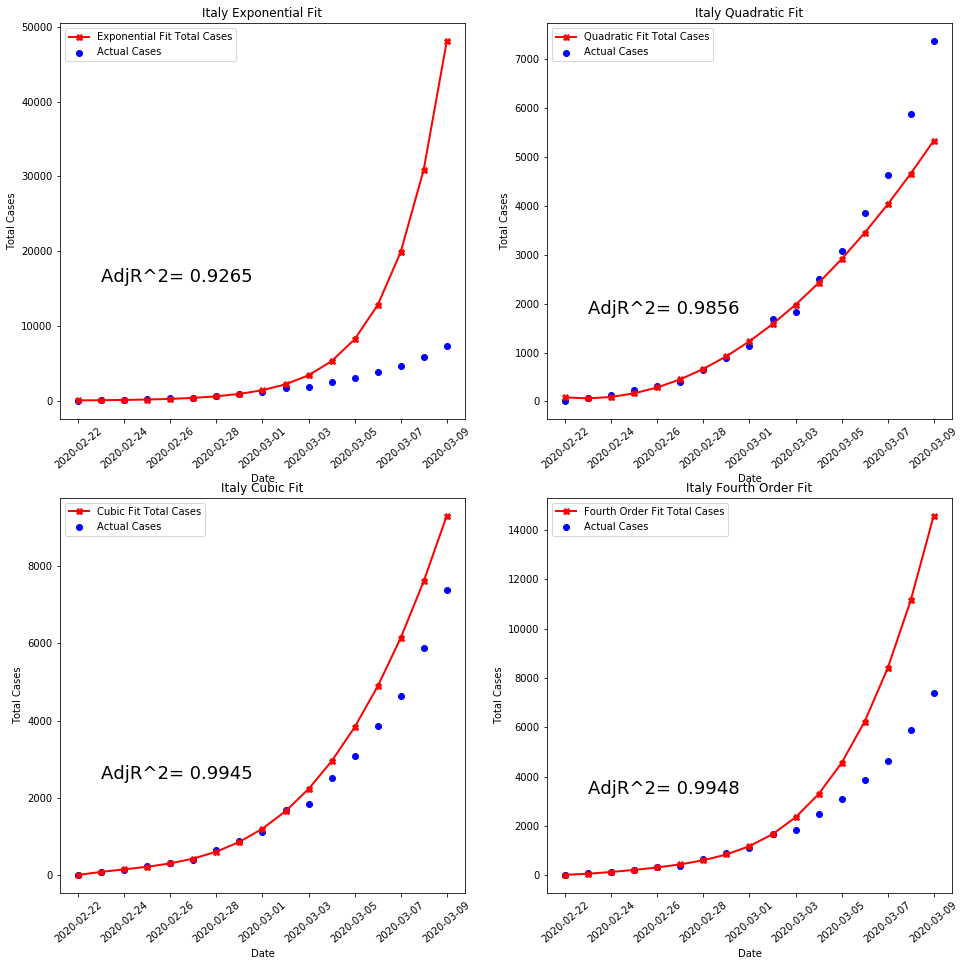

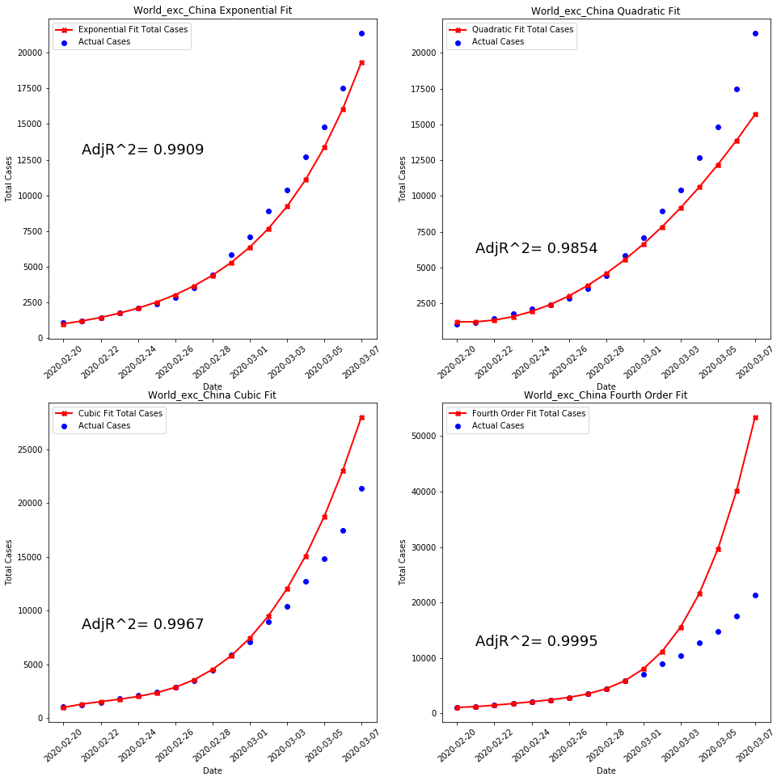

When the USA had the some number of data points as Turkey today, the red line shows the fitted values and blue dots show the real actualized value.

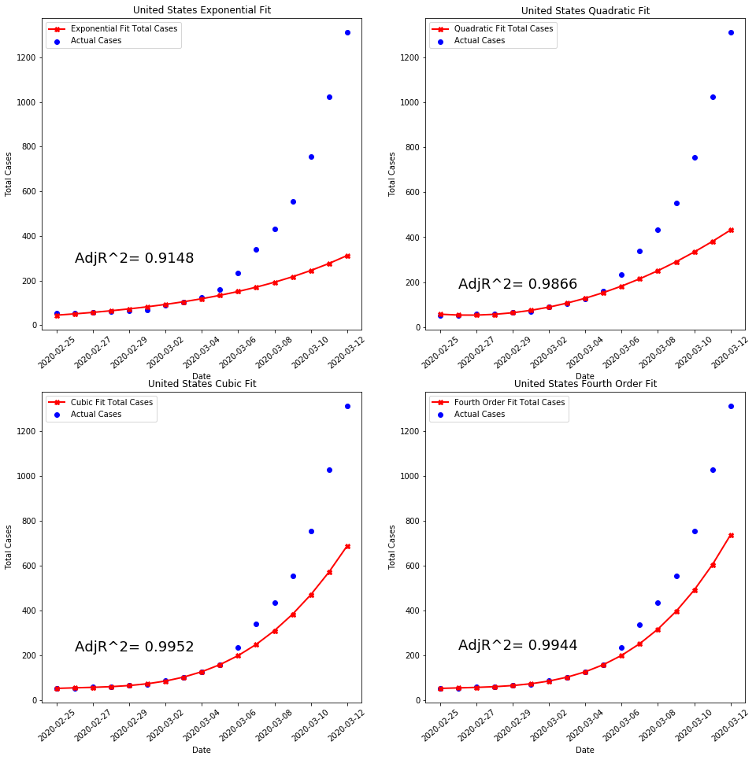

When Germany had the some number of data points as Turkey today, the red line shows the fitted values and blue dots show the real actualized value.

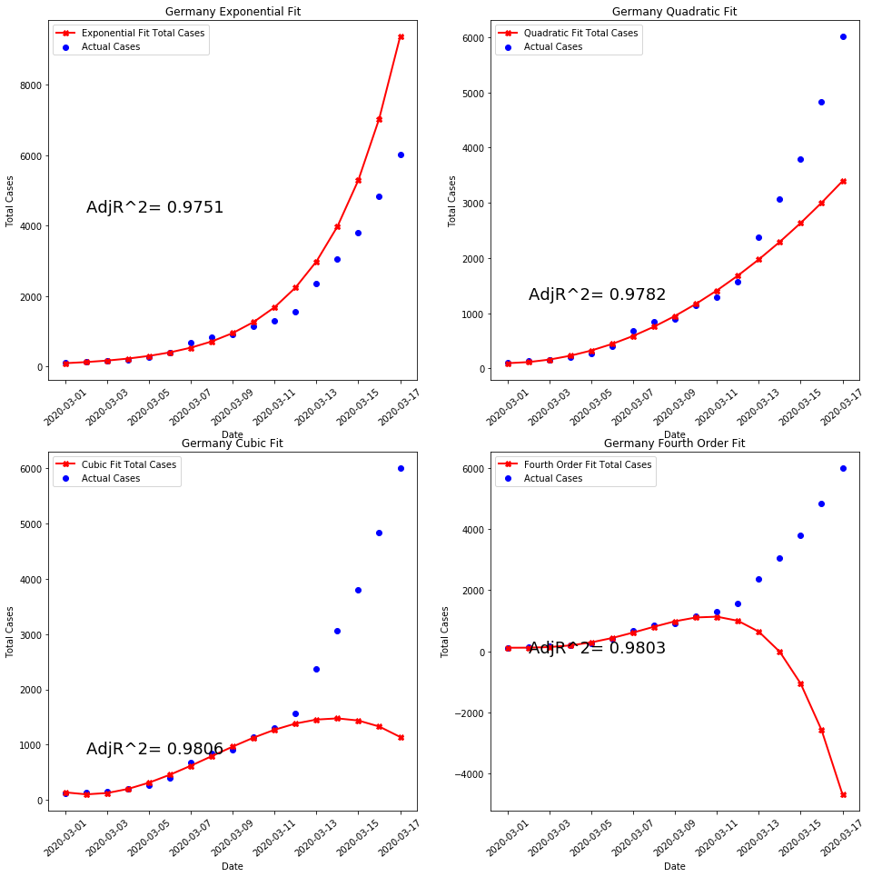

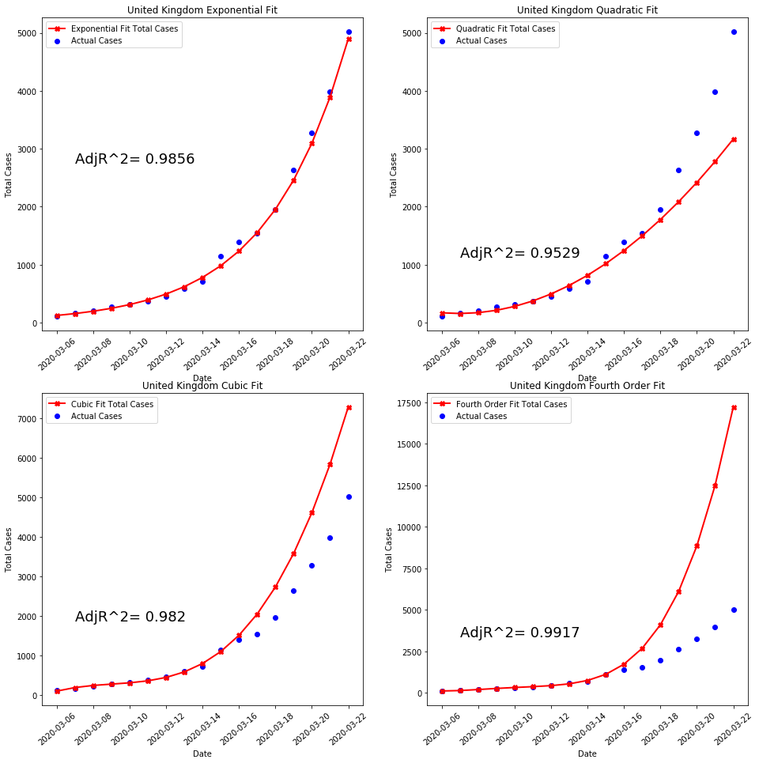

## World excluding China Different Fits Comparison

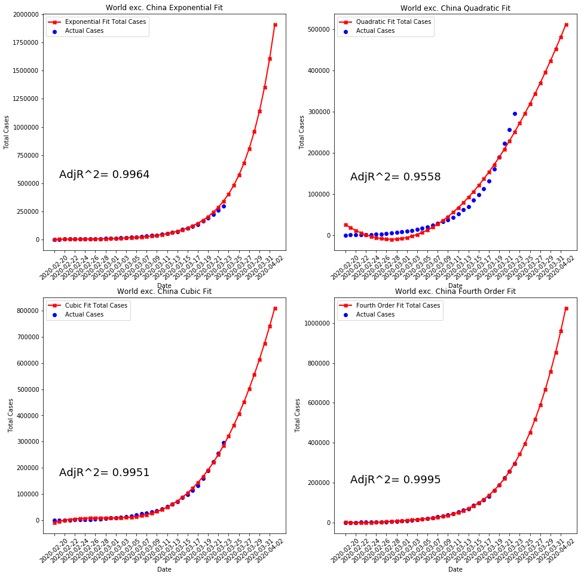

## Turkey Different Fits Comparison

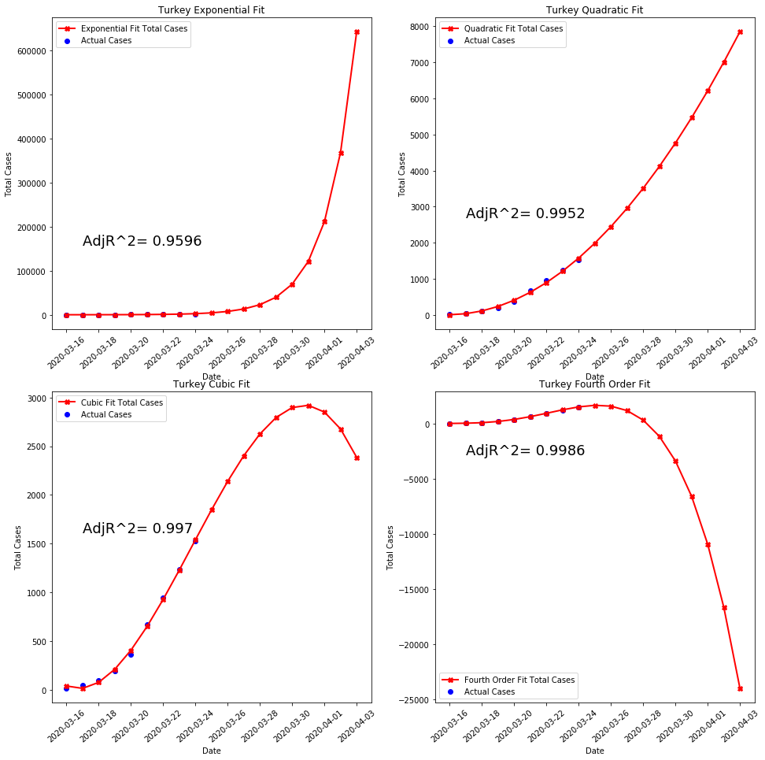

## Italy Different Fits Comparison

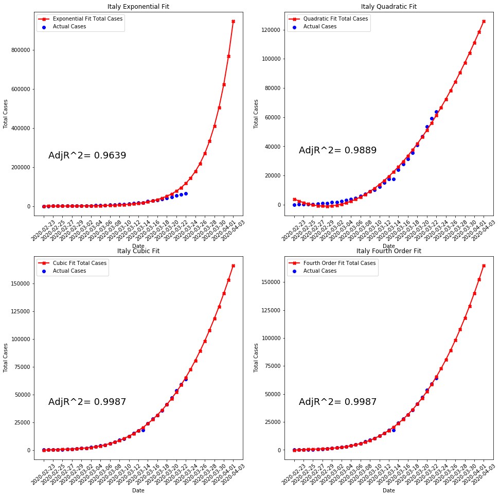

## Spain Different Fits Comparison

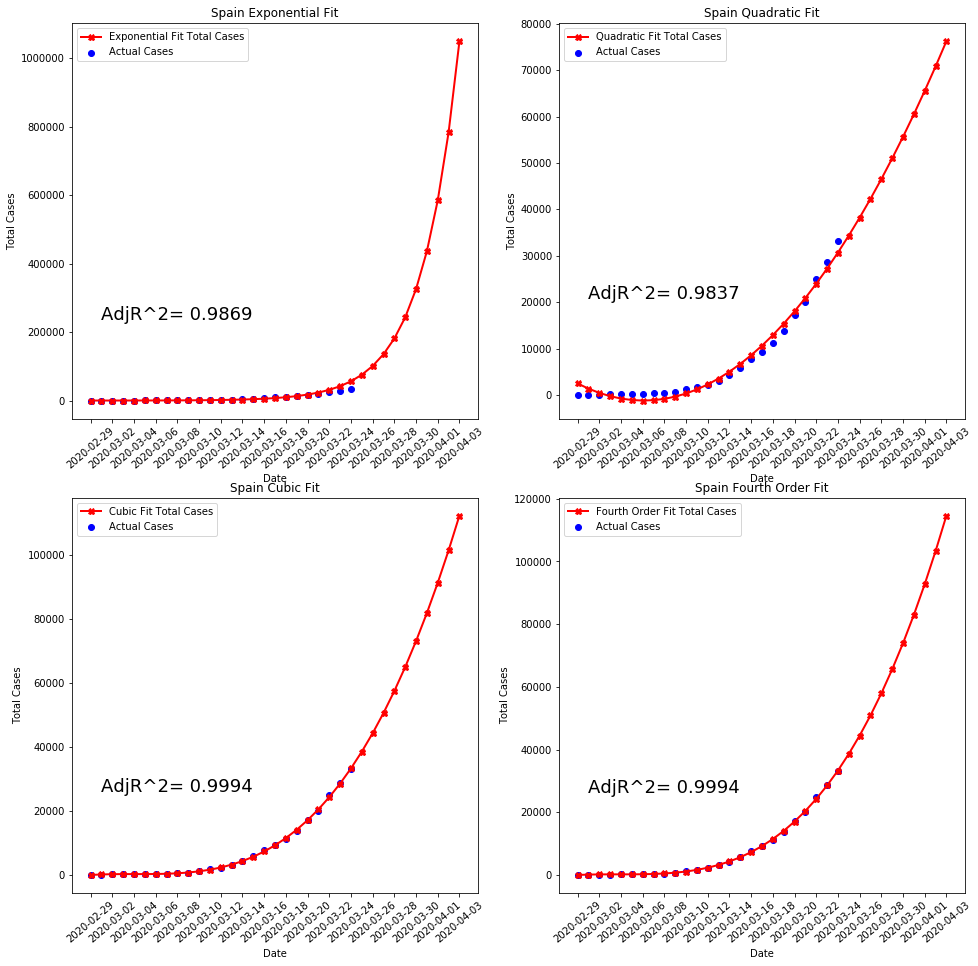

## United States Different Fits Comparison

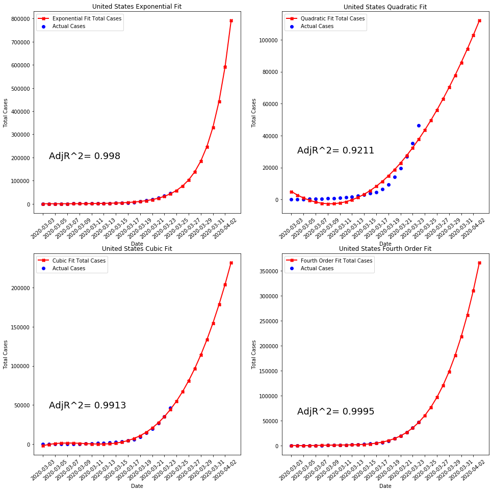

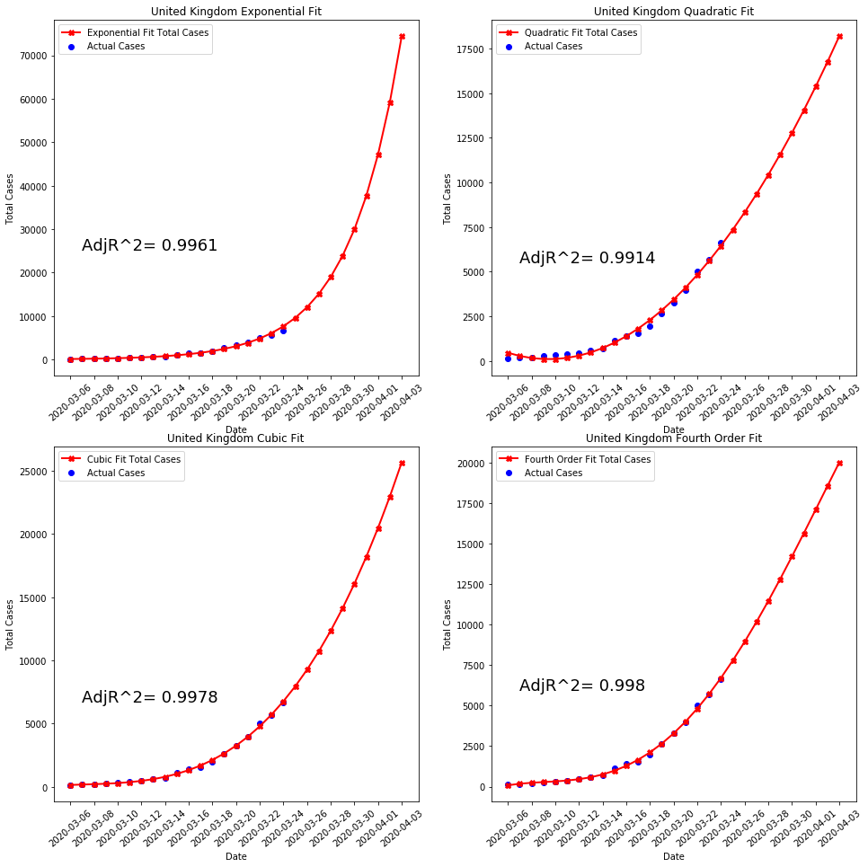

## Cubic Forecasts for Some Countries

## World excluding China

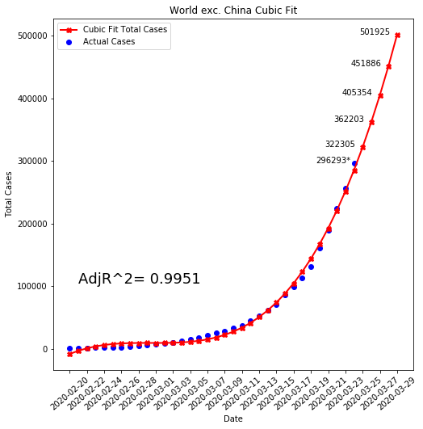

### Turkey

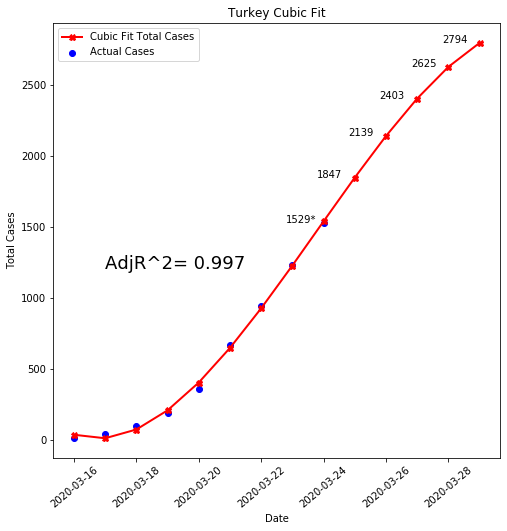

### Italy

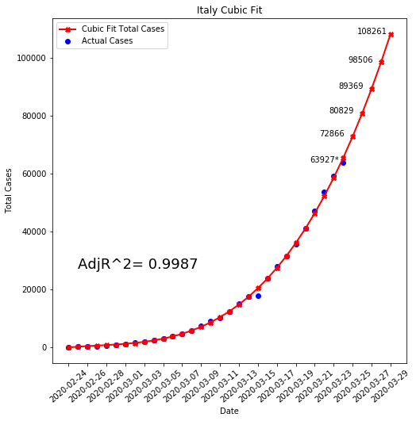

### United States

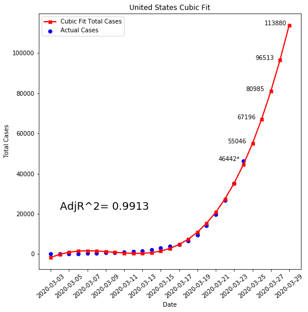

### Spain

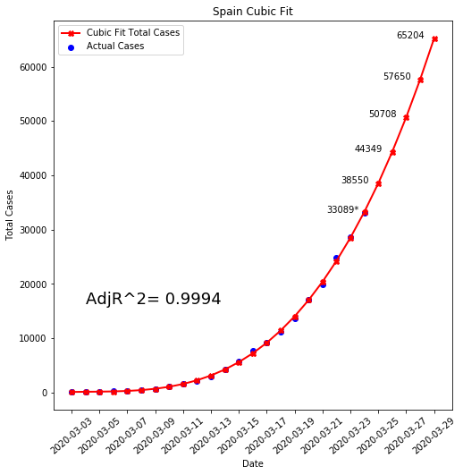

### Germany

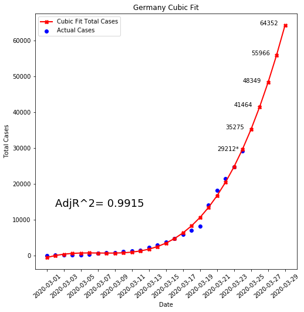

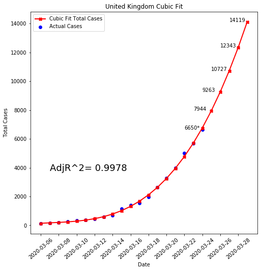

# Exponential Smoothing

## World Excluding Cigna Exponential Smoothing (Yellow Curve Performs the Best for 1 Day Ahead)

```
Series([], Name: exc_China, dtype: int64)
```

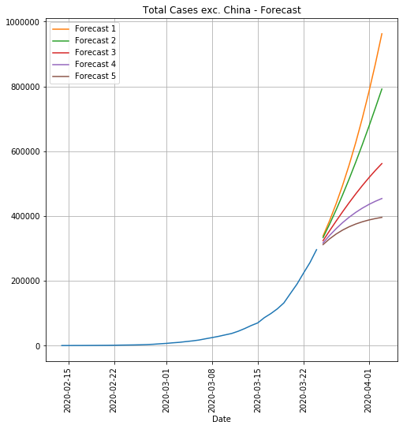

|  | Exponential Damped Trend1 | Exponential Damped Trend2 | Exponential Damped Trend3 | Exponential Damped Trend4 | Exponential Damped Trend5 |
| --- | --- | --- | --- | --- | --- |
| 2020-03-25 | 338633.1 | 333716.8 | 324203.2 | 317290.7 | 312022.6 |
| 2020-03-26 | 385913.6 | 375088.0 | 354655.6 | 340294.5 | 329674.6 |
| 2020-03-27 | 438074.4 | 419131.7 | 384501.0 | 361154.4 | 344512.5 |
| 2020-03-28 | 495397.6 | 465754.5 | 413503.4 | 379887.7 | 356862.2 |
| 2020-03-29 | 558158.8 | 514841.1 | 441471.3 | 396573.0 | 367059.9 |
| 2020-03-30 | 626624.8 | 566257.0 | 468256.2 | 411330.5 | 375427.5 |
| 2020-03-31 | 701051.4 | 619850.4 | 493749.3 | 424305.3 | 382258.8 |
| 2020-04-01 | 781681.6 | 675455.3 | 517877.7 | 435655.2 | 387813.1 |
| 2020-04-02 | 868743.3 | 732893.3 | 540599.7 | 445541.0 | 392314.7 |
| 2020-04-03 | 962447.9 | 791977.4 | 561900.6 | 454120.1 | 395953.5 |
| 2020-04-04 | 1062988.2 | 852513.3 | 581788.2 | 461542.2 | 398888.9 |
| 2020-04-05 | 1170536.9 | 914302.9 | 600288.1 | 467946.2 | 401252.8 |
| 2020-04-06 | 1285245.4 | 977146.4 | 617440.4 | 473459.4 | 403154.1 |
| 2020-04-07 | 1407242.6 | 1040844.1 | 633296.2 | 478196.7 | 404681.5 |
| 2020-04-08 | 1536633.9 | 1105198.8 | 647914.2 | 482260.6 | 405907.7 |
| 2020-04-09 | 1673500.4 | 1170017.6 | 661358.7 | 485742.1 | 406891.3 |
| 2020-04-10 | 1817898.1 | 1235113.3 | 673697.1 | 488721.1 | 407679.9 |
| 2020-04-11 | 1969858.2 | 1300305.8 | 684998.3 | 491267.6 | 408311.8 |
| 2020-04-12 | 2129386.1 | 1365423.1 | 695331.5 | 493442.6 | 408818.1 |
| 2020-04-13 | 2296462.2 | 1430302.5 | 704764.5 | 495298.9 | 409223.6 |

## Turkey Exponential Smoothing (Purple Curve Performs the Best for 1 Day Ahead)

```
Series([], Name: Turkey, dtype: float64)
```

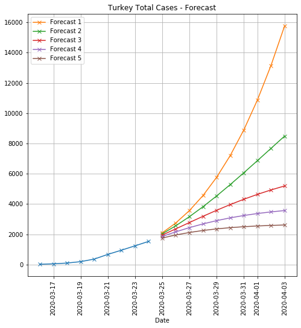

|  | Exponential Damped Trend 0.95 | Exponential Damped Trend 0.90 | Exponential Damped Trend 0.85 | Exponential Damped Trend 0.8 | Exponential Damped Trend 0.75 |
| --- | --- | --- | --- | --- | --- |
| 2020-03-25 | 2091.9 | 2028.3 | 1947.2 | 1859.4 | 1753.3 |
| 2020-03-26 | 2749.0 | 2562.2 | 2358.2 | 2161.4 | 1953.0 |
| 2020-03-27 | 3563.5 | 3162.0 | 2775.0 | 2438.0 | 2117.6 |
| 2020-03-28 | 4559.7 | 3820.9 | 3186.8 | 2684.5 | 2250.1 |
| 2020-03-29 | 5763.0 | 4530.5 | 3584.5 | 2899.5 | 2354.9 |
| 2020-03-30 | 7198.9 | 5281.2 | 3961.3 | 3083.9 | 2436.6 |
| 2020-03-31 | 8893.3 | 6062.6 | 4312.6 | 3239.8 | 2499.8 |
| 2020-04-01 | 10870.8 | 6864.2 | 4635.6 | 3370.2 | 2548.3 |
| 2020-04-02 | 13155.4 | 7675.9 | 4929.1 | 3478.3 | 2585.3 |
| 2020-04-03 | 15769.1 | 8488.2 | 5193.1 | 3567.2 | 2613.3 |

## Italy Exponential Smoothing (Red Curve Performs the Best for 1 Day Ahead)

```
Series([], Name: Italy, dtype: int64)
```

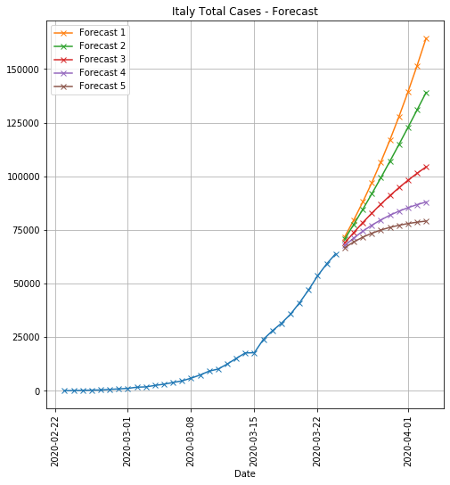

|  | Exponential Damped Trend 0.97 | Exponential Damped Trend 0.95 | Exponential Damped Trend 0.90 | Exponential Damped Trend 0.85 | Exponential Damped Trend 0.80 |
| --- | --- | --- | --- | --- | --- |
| 2020-03-25 | 71782.2 | 70805.4 | 68955.2 | 67671.4 | 66727.8 |
| 2020-03-26 | 79621.8 | 77572.2 | 73783.4 | 71232.1 | 69406.7 |
| 2020-03-27 | 88043.4 | 84598.6 | 78417.1 | 74405.7 | 71627.1 |
| 2020-03-28 | 97062.6 | 91862.4 | 82835.8 | 77214.1 | 73454.4 |
| 2020-03-29 | 106693.1 | 99339.8 | 87025.1 | 79684.4 | 74949.8 |
| 2020-03-30 | 116946.7 | 107006.4 | 90976.3 | 81846.3 | 76168.0 |
| 2020-03-31 | 127833.4 | 114837.0 | 94685.5 | 83729.9 | 77156.8 |
| 2020-04-01 | 139360.9 | 122806.2 | 98153.0 | 85365.0 | 77957.1 |
| 2020-04-02 | 151534.8 | 130888.7 | 101382.1 | 86779.9 | 78603.3 |
| 2020-04-03 | 164358.8 | 139059.1 | 104379.1 | 88001.0 | 79124.1 |

## US Exponential Smoothing (Yellow Performs the Best for 1 Day Ahead)

```
Series([], Name: United States, dtype: int64)
```

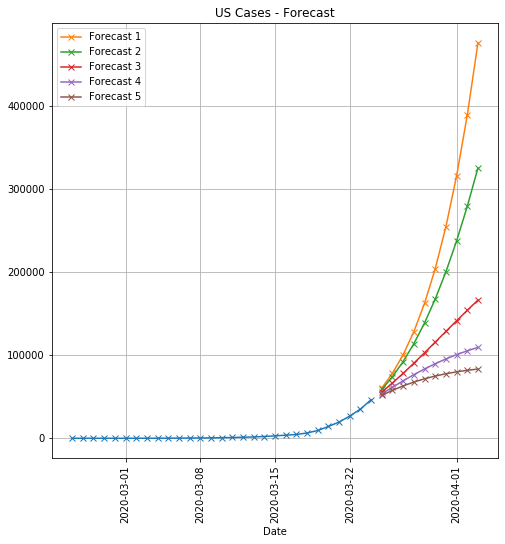

|  | Exponential Damped Trend 0.97 | Exponential Damped Trend 0.95 | Exponential Damped Trend 0.90 | Exponential Damped Trend 0.85 | Exponential Damped Trend 0.80 |
| --- | --- | --- | --- | --- | --- |
| 2020-03-25 | 60540.2 | 58861.2 | 55686.9 | 53420.0 | 51709.5 |
| 2020-03-26 | 78349.1 | 74162.1 | 66569.6 | 61433.6 | 57734.7 |
| 2020-03-27 | 100615.4 | 92367.1 | 78171.1 | 69183.5 | 63056.5 |
| 2020-03-28 | 128243.7 | 113785.2 | 90331.6 | 76534.9 | 67665.0 |
| 2020-03-29 | 162273.1 | 138715.7 | 102885.4 | 83394.6 | 71593.2 |
| 2020-03-30 | 203887.5 | 167441.7 | 115668.8 | 89706.6 | 74899.3 |
| 2020-03-31 | 254425.4 | 200223.4 | 128526.5 | 95446.1 | 77653.7 |
| 2020-04-01 | 315387.9 | 237292.2 | 141316.1 | 100612.4 | 79930.1 |
| 2020-04-02 | 388446.5 | 278845.5 | 153911.3 | 105223.1 | 81799.1 |
| 2020-04-03 | 475447.7 | 325042.2 | 166204.0 | 109308.0 | 83325.7 |

## Spain Exponential Smoothing (Green Curve Performs the Best for 1 Day Ahead)

```
Series([], Name: Spain, dtype: int64)
```

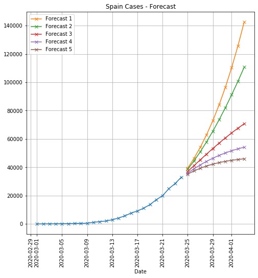

|  | Exponential Damped Trend 0.97 | Exponential Damped Trend 0.95 | Exponential Damped Trend 0.90 | Exponential Damped Trend 0.85 | Exponential Damped Trend 0.80 |
| --- | --- | --- | --- | --- | --- |
| 2020-03-25 | 39393.0 | 38603.2 | 37044.2 | 35978.0 | 35216.2 |
| 2020-03-26 | 46273.9 | 44514.4 | 41173.5 | 38979.0 | 37459.2 |
| 2020-03-27 | 54094.7 | 50966.4 | 45282.0 | 41725.8 | 39356.0 |
| 2020-03-28 | 62941.9 | 57959.9 | 49329.1 | 44212.2 | 40942.4 |
| 2020-03-29 | 72903.9 | 65490.7 | 53279.8 | 46441.9 | 42257.4 |
| 2020-03-30 | 84071.2 | 73549.3 | 57105.2 | 48425.3 | 43339.8 |
| 2020-03-31 | 96535.5 | 82121.7 | 60782.4 | 50177.6 | 44225.6 |
| 2020-04-01 | 110389.0 | 91189.2 | 64293.9 | 51716.8 | 44947.3 |
| 2020-04-02 | 125723.7 | 100729.0 | 67627.3 | 53062.3 | 45533.1 |
| 2020-04-03 | 142631.0 | 110714.6 | 70775.0 | 54233.4 | 46007.3 |

## UK Exponential Smoothing (Green Curve Performs the Best for 1 Day Ahead)

```
Series([], Name: United Kingdom, dtype: int64)
```

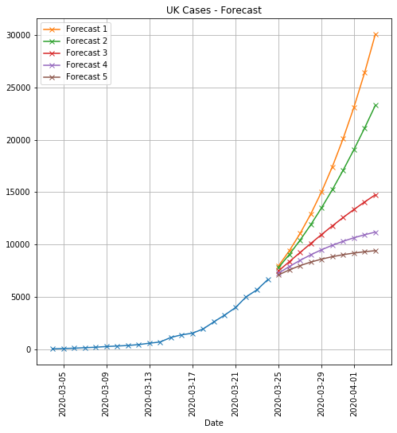

|  | Exponential Damped Trend 0.97 | Exponential Damped Trend 0.95 | Exponential Damped Trend 0.90 | Exponential Damped Trend 0.85 | Exponential Damped Trend 0.80 |
| --- | --- | --- | --- | --- | --- |
| 2020-03-25 | 7958.4 | 7801.5 | 7486.3 | 7265.4 | 7105.0 |
| 2020-03-26 | 9398.3 | 9044.8 | 8362.5 | 7904.3 | 7582.6 |
| 2020-03-27 | 11043.5 | 10409.0 | 9238.5 | 8491.4 | 7987.8 |
| 2020-03-28 | 12914.0 | 11895.1 | 10105.0 | 9024.6 | 8327.4 |
| 2020-03-29 | 15030.6 | 13503.0 | 10954.2 | 9504.1 | 8609.5 |
| 2020-03-30 | 17414.6 | 15231.3 | 11779.3 | 9931.6 | 8842.1 |
| 2020-03-31 | 20087.9 | 17077.8 | 12574.9 | 10310.0 | 9032.6 |
| 2020-04-01 | 23072.5 | 19038.8 | 13336.8 | 10643.1 | 9188.0 |
| 2020-04-02 | 26390.5 | 21109.9 | 14061.9 | 10934.6 | 9314.2 |
| 2020-04-03 | 30064.4 | 23285.8 | 14748.1 | 11188.6 | 9416.5 |